# Weakly Supervised Learning: Label Noise and Correction

Applied Data Science Project 3

Marcus Loke, Sarah Kurihara, Shintaro Nakamura, Yinan Shi, Yixuan Zhang

Spring 2022

```r
# Load required libraries
library(reticulate)
library(keras) # high-level neural networks API, written in Python and capable of running on top of TensorFlow
library(tensorflow)
library(nnet)
library(dplyr)
library(png)
library(glue)
library(stringr)
library(caret)
library(tidyr)
library(ggplot2)

# Sets all random seeds needed to make TensorFlow code reproducible
set_random_seed(100)
```

# 1 Load the datasets

For the project, we provide a training set with 50,000 images in the directory `../data/images/` with:

- noisy labels for all images provided in `../data/noisy_labels.csv`;
- clean labels for the first 10,000 images provided in `../data/clean_labels.csv`.

```r
# Load the images
n_img = 50000
n_noisy = 40000
n_clean_noisy = n_img - n_noisy
imgs = array(NA, c(n_img,32,32,3))

for (i in 1:n_img) {
  img_fn = glue("../data/images/{str_pad(i, 5, pad='0')}.png")
  imgs[i,,,] = readPNG(img_fn)
  i = i + 1
}

# Load the labels
clean_labels = as.matrix(read.csv("../data/clean_labels.csv", header=F))
noisy_labels = as.matrix(read.csv("../data/noisy_labels.csv", header=F))

# Combine into lists
cifar = list()
cifar$train$x = imgs
cifar$train$y = noisy_labels
cifar$test$x = imgs[1:10000,,,]
cifar$test$y = clean_labels
```

## 1.1 Verify the data

For illustration, we present a small subset (of size 8) of the images with their clean and noisy labels in `clean_noisy_trainset`. You are encouraged to explore more characteristics of the label noises on the whole dataset.

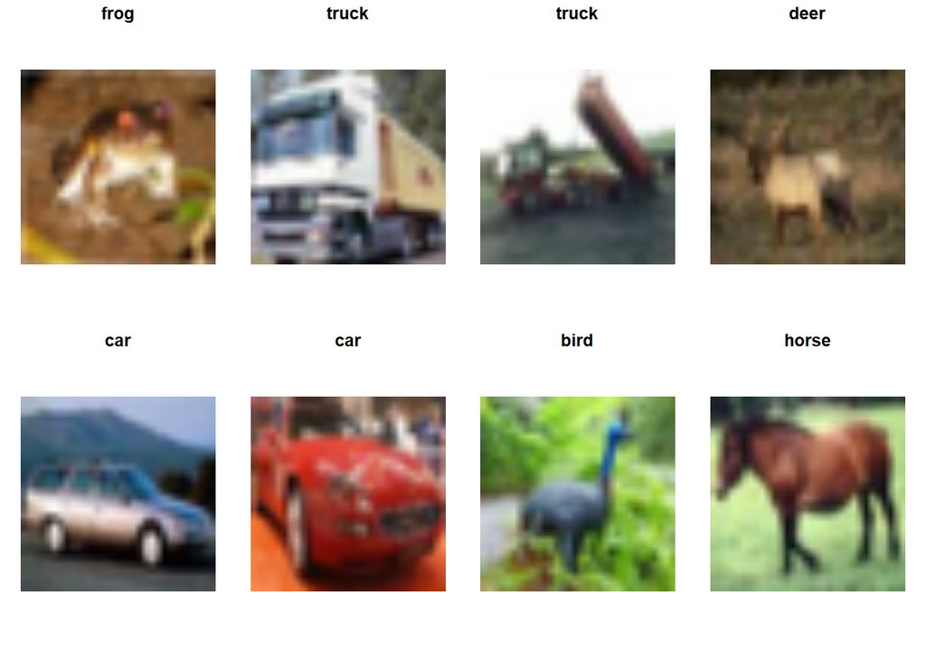

```r
# The class label correspondence
classes = c('plane', 'car', 'bird', 'cat',
            'deer', 'dog', 'frog', 'horse', 'ship', 'truck')

index = 1:8

# Print clean labels
par(mfrow = c(2,4), mar = rep(1, 4), oma = rep(0.2, 4))
cifar$train$x[index,,,] %>%
  purrr::array_tree(1) %>%
  purrr::set_names(classes[clean_labels[index] + 1]) %>%
  purrr::map(as.raster, max = 1) %>%
  purrr::iwalk(~{plot(.x); title(.y)})
```

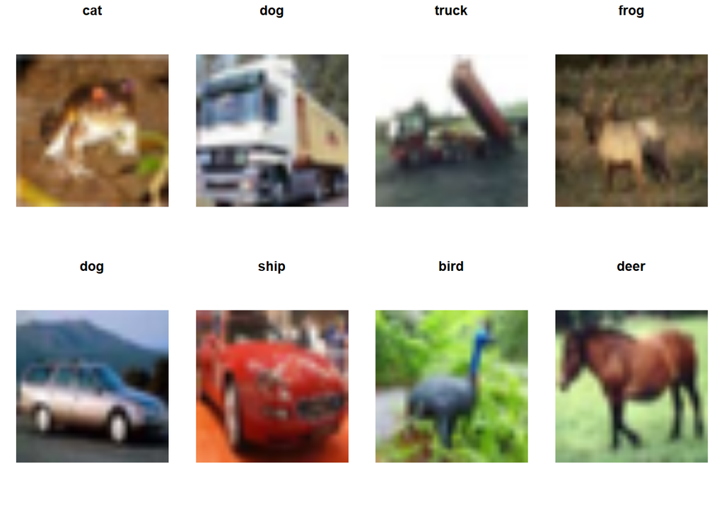

```r
# Print noisy labels
par(mfrow = c(2,4), mar = rep(1, 4), oma = rep(0.2, 4))
cifar$train$x[index,,,] %>%
  purrr::array_tree(1) %>%
  purrr::set_names(classes[noisy_labels[index] + 1]) %>%
  purrr::map(as.raster, max = 1) %>%
  purrr::iwalk(~{plot(.x); title(.y)})
```

# 2 The predictive models

## 2.1 Baseline model

We consider a baseline model directly on the noisy dataset without any label corrections. RGB histogram features are extracted to fit a logistic regression model.

```r
# RGB histogram data construction
no_bins = 6
bins = array(seq(0, 1, length.out=no_bins)) # the range of the rgb histogram
target_vec = array(NA, n_img)
feature_mtx = array(NA, c(n_img,3*(length(bins)-1)))
i = 0

for (i in 1:n_img) {
  # The target vector consists of noisy labels
  target_vec[i] = noisy_labels[i]

  # Use the number of pixels in each bin for all three channels as features
  feature1 = array(hist(imgs[i,,,1], breaks = bins, plot = F)$counts)
  feature2 = array(hist(imgs[i,,,2], breaks = bins, plot = F)$counts)
  feature3 = array(hist(imgs[i,,,3], breaks = bins, plot = F)$counts)

  # Concatenate three features
  feature_mtx[i,] = c(feature1, feature2, feature3)
  i = i + 1
}
```

```r
# Train a multinomial logistic regression model with last 40,000 images
df_feature_mtx = cbind(as.data.frame(feature_mtx[10001:50000,]),
                       as.data.frame(target_vec[10001:50000])) %>%
  rename(target_vec = `target_vec[10001:50000]`)
clf = multinom(target_vec~., data = df_feature_mtx)

# Extract features for first 10,000 images (clean labels)
feature = array(NA, c(n_clean_noisy,3*(length(bins)-1)))
i = 0

for (i in 1:n_clean_noisy) {
  # Use the number of pixels in each bin for all three channels as features
  feature1 = array(hist(imgs[i,,,1], breaks = bins, plot = F)$counts)
  feature2 = array(hist(imgs[i,,,2], breaks = bins, plot = F)$counts)
  feature3 = array(hist(imgs[i,,,3], breaks = bins, plot = F)$counts)

  # Concatenate three features
  feature[i,] = c(feature1, feature2, feature3)
  i = i + 1
}
```

For the convenience of evaluation, we write the following function `baseline_model` that does the label prediction. For your predictive model, feel free to modify the function, but make sure the function takes RGB images of format with dimension $32 \times 32 \times 3$ as input, and returns labels as output.

```r
# This is the baseline predictive model that takes in an array of images and returns the label predictions
baseline_model <- function(images) {
  # Initialize vars
  feature = array(NA, c(nrow(images),3*(length(bins)-1)))
  i = 0

  for (i in 1:nrow(images)) {
    # Use the number of pixels in each bin for all three channels as features
    feature1 = array(hist(images[i,,,1], breaks = bins, plot = F)$counts)
    feature2 = array(hist(images[i,,,2], breaks = bins, plot = F)$counts)
    feature3 = array(hist(images[i,,,3], breaks = bins, plot = F)$counts)

    # Concatenate three features
    feature[i,] = c(feature1, feature2, feature3)
    i = i + 1
  }

  # Predict labels
  return(predict(clf, as.data.frame(feature)))
}
```

Also, for convenience of showing the results like precision, recall, F1 score, accuracy, etc., the following function is created to produce the classification report.

```r
# Function to produce classification report
# cm = confusion matrix; dp = no. of decimal places
class_report <- function(cm, dp=2) {
  ct <- sum(cm)
  cs <- colSums(cm)
  rs <- rowSums(cm)
  tp <- diag(cm)
  tn <- ct - (rs + cs - tp)
  fp <- rs - tp
  fn <- cs - tp
  pr <- tp / (tp + fp)
  re <- tp / (tp + fn)
  f1 <- 2 * pr * re / (pr + re)
  ac <- sum(tp) / ct
  list(summary=round(data.frame(tp, tn, fp, fn, precision=pr, recall=re, f1_score=f1, support=cs), dp),
       accuracy=round(ac, dp),
       support=ct)
}
```

## 2.2 Model 1: CNN

Here we build a convolutional neural network (CNN) that’s trained on the last 40,000 images with noisy labels (i.e., image #10,001 to #50,000) and tested on the first 10,000 images with clean labels (i.e., image #1 to #10,000). This way of segmenting the data into train and validation sets are in the proportion of 80% to 20% respectively.

```r
# Sequential = layer by layer building; not possible to share layers
model <- keras_model_sequential() %>%
  layer_conv_2d(filters = 32, kernel_size = c(3,3), activation = "relu",
                input_shape = c(32,32,3)) %>%
  layer_max_pooling_2d(pool_size = c(2,2)) %>%
  layer_conv_2d(filters = 64, kernel_size = c(3,3), activation = "relu") %>%
  layer_max_pooling_2d(pool_size = c(2,2)) %>%
  layer_conv_2d(filters = 64, kernel_size = c(3,3), activation = "relu")

# Now flatten and apply neural net calculation
model %>%
  layer_flatten() %>%
  layer_dense(units = 64, activation = "relu") %>%
  layer_dense(units = 10, activation = "softmax")

# Compile and train model
model %>%
  compile(
    optimizer = "adam",
    loss = "sparse_categorical_crossentropy",
    metrics = "accuracy"
  )

# Fit the model
start_time = Sys.time()
results_train <- model %>%
  fit(
    x = cifar$train$x[10001:50000,,,], y = cifar$train$y[10001:50000],
    epochs = 10,
    validation_data = unname(cifar$test),
    verbose = 2
  )
end_time = Sys.time()

# Time taken to train model
end_time - start_time
```

```
## Time difference of 5.405625 mins
```

For the convenience of evaluation, we write the following function `cnn_model1` that does the label prediction. The function takes in RGB images of format with dimension $32 \times 32 \times 3$ as input, and returns labels as output.

```r
# This is the CNN predictive model that takes in an array of images and returns the label predictions
cnn_model1 <- function(images) {
  # Predict labels
  pred1 = model %>%
    predict(images) %>%
    k_argmax() %>%
    as.matrix() %>%
    as.factor()
  return(pred1)
}
```

### 2.2.1 5-fold CV

```r
# DO NOT RUN - RUNS CV TO DETERMINE EXPECTED ACCURACY ON UNSEEN DATA
# Create 5 folds that stores the indexes for each fold
set.seed(100)
folds = createFolds(cifar$train$x[10001:50000], k=5, list=TRUE, returnTrain=FALSE)

# Initialize vars
i = 1
acc_cv = NA

# Initlize CNN for CV
# Sequential = layer by layer building; not possible to share layers
model_cv <- keras_model_sequential() %>%
  layer_conv_2d(filters = 32, kernel_size = c(3,3), activation = "relu",
                input_shape = c(32,32,3)) %>%
  layer_max_pooling_2d(pool_size = c(2,2)) %>%
  layer_conv_2d(filters = 64, kernel_size = c(3,3), activation = "relu") %>%
  layer_max_pooling_2d(pool_size = c(2,2)) %>%
  layer_conv_2d(filters = 64, kernel_size = c(3,3), activation = "relu")

# Now flatten and apply neural net calculation
model_cv %>%
  layer_flatten() %>%
  layer_dense(units = 64, activation = "relu") %>%
  layer_dense(units = 10, activation = "softmax")

# Compile and train model
model_cv %>%
  compile(
    optimizer = "adam",
    loss = "sparse_categorical_crossentropy",
    metrics = "accuracy"
  )

# Perform 5-fold CV on the last 40,000 images
for (i in 1:length(folds)) {
  # Train CNN model on all images except i-th fold
  model_cv %>%
    fit(
      x = cifar$train$x[unlist(folds[-i])+10000,,,], y = cifar$train$y[unlist(folds[-i])+10000],
      epochs = 10,
      validation_data = list(cifar$train$x[folds[[i]]+10000,,,],
                             cifar$train$y[folds[[i]]+10000]),
      #validation_data = unname(cifar$test),
      verbose = 2
    )

  # Predict on i-th fold
  valid_cv = as.factor(cifar$train$y[folds[[i]]+10000])
  pred_cv = model_cv %>%
    predict(cifar$train$x[folds[[i]]+10000,,,]) %>%
    k_argmax() %>%
    as.matrix() %>%
    as.factor()

  # Store accuracy
  acc_cv[i]= class_report(table(pred_cv, valid_cv))$accuracy
}

# Average accuracy across 5-folds
mean(acc_cv)
```

## 2.3 Model 2: WSL with CNN

Here we approached the prediction modelling process in two main steps: First, we will train a CNN that does the label correction (i.e., mapping noisy labels to cleaned labels, conditioned on the input image). Then we use this CNN to correct the noisy labels to get cleaned ones, which will then be used to train our CNN in Model 1 for image classification.

- **Step 1**: Train a label correction network on the first 7,000 images with clean labels (leave the remaining 3,000 images with clean labels for validation purposes in Step 2) and predict on the last 40,000 images to correct their labels.
- **Step 2**: Once the labels have been corrected, we will re-train a new CNN (similar to Model 1) on the last 40,000 images and predict on the remaining 3,000 images for validation purposes.

### 2.3.1 Label correction network

First, we train a label correction network using CNN on the first 7,000 images with clean labels.

```r
# Sequential = layer by layer building; not possible to share layers
model_labcor <- keras_model_sequential() %>%
  layer_conv_2d(filters = 32, kernel_size = c(3,3), activation = "relu",
                input_shape = c(32,32,3)) %>%
  layer_max_pooling_2d(pool_size = c(2,2)) %>%
  layer_conv_2d(filters = 64, kernel_size = c(3,3), activation = "relu") %>%
  layer_max_pooling_2d(pool_size = c(2,2)) %>%
  layer_conv_2d(filters = 64, kernel_size = c(3,3), activation = "relu")

# Now flatten and apply neural net calculation
model_labcor %>%
  layer_flatten() %>%
  layer_dense(units = 64, activation = "relu") %>%
  layer_dense(units = 10, activation = "softmax")

# Compile and train model
model_labcor %>%
  compile(
    optimizer = "adam",
    loss = "sparse_categorical_crossentropy",
    metrics = "accuracy"
  )

# Fit the model
start_time = Sys.time()
model_labcor %>%
  fit(
    x = cifar$train$x[1:7000,,,], y = cifar$test$y[1:7000],
    epochs = 10,
    validation_data = list(cifar$test$x[7001:10000,,,],
                           cifar$test$y[7001:10000]),
    verbose = 2
  )
end_time = Sys.time()

# Time taken to train model
end_time - start_time
```

```
## Time difference of 1.039868 mins
```

Predict on last 40,000 images to correct their labels.

```r
pred_labcor = model_labcor %>%
  predict(imgs[10001:50000,,,]) %>%
  k_argmax() %>%
  as.matrix() %>%
  as.factor()
```

### 2.3.2 Model 2

Now that the labels have been corrected for the last 40,000 images, we will re-train a CNN on the 40,000 images and evaluate its performance on the remaining 3,000 images with clean labels.

```r
# Sequential = layer by layer building; not possible to share layers
model2 <- keras_model_sequential() %>%
  layer_conv_2d(filters = 32, kernel_size = c(3,3), activation = "relu",
                input_shape = c(32,32,3)) %>%
  layer_max_pooling_2d(pool_size = c(2,2)) %>%
  layer_conv_2d(filters = 64, kernel_size = c(3,3), activation = "relu") %>%
  layer_max_pooling_2d(pool_size = c(2,2)) %>%
  layer_conv_2d(filters = 64, kernel_size = c(3,3), activation = "relu")

# Now flatten and apply neural net calculation
model2 %>%
  layer_flatten() %>%
  layer_dense(units = 64, activation = "relu") %>%
  layer_dense(units = 10, activation = "softmax")

# Compile and train model
model2 %>%
  compile(
    optimizer = "adam",
    loss = "sparse_categorical_crossentropy",
    metrics = "accuracy"
  )

# Fit the model
start_time = Sys.time()
results_train2 <- model2 %>%
  fit(
    x = cifar$train$x[10001:50000,,,], y = as.matrix(as.numeric(pred_labcor))-1,
    epochs = 10,
    validation_data = list(cifar$test$x[7001:10000,,,],
                           cifar$test$y[7001:10000]),
    verbose = 2
  )
end_time = Sys.time()

# Time taken to train model
end_time - start_time
```

```
## Time difference of 5.287746 mins
```

For the convenience of evaluation, we write the following function `cnn_model2` that does the label prediction. The function takes in RGB images of format with dimension $32 \times 32 \times 3$ as input, and returns labels as output.

```r
# This is the CNN predictive model that takes in an array of images and returns the label predictions
cnn_model2 <- function(images) {
  # Predict labels
  pred2 = model2 %>%
    predict(images) %>%
    k_argmax() %>%
    as.matrix() %>%
    as.factor()
  return(pred2)
}
```

# 3 Evaluation

This section covers the model evaluation on the training data.

## 3.1 Baseline model

Evaluate baseline model on the validation set, which contains the first 10,000 images with clean labels. The accuracy of the model is 23%.

```r
# Predict on first 10,000 images and show results
valid = as.factor((as.data.frame(clean_labels))$V1)
pred = baseline_model(imgs[1:10000,,,])
class_report(table(pred, valid))
```

```
## $summary
##    tp   tn   fp   fn precision recall f1_score support
## 0 514 7727 1268  491      0.29   0.51     0.37    1005
## 1 271 7909 1117  703      0.20   0.28     0.23     974
## 2  21 8927   41 1011      0.34   0.02     0.04    1032
## 3  86 8551  433  930      0.17   0.08     0.11    1016
## 4 581 6759 2242  418      0.21   0.58     0.30     999
## 5 177 8405  658  760      0.21   0.19     0.20     937
## 6 330 7950 1020  700      0.24   0.32     0.28    1030
## 7  19 8955   44  982      0.30   0.02     0.04    1001
## 8 248 8503  472  777      0.34   0.24     0.28    1025
## 9  85 8646  373  896      0.19   0.09     0.12     981
##
## $accuracy
## [1] 0.23
##
## $support
## [1] 10000
```

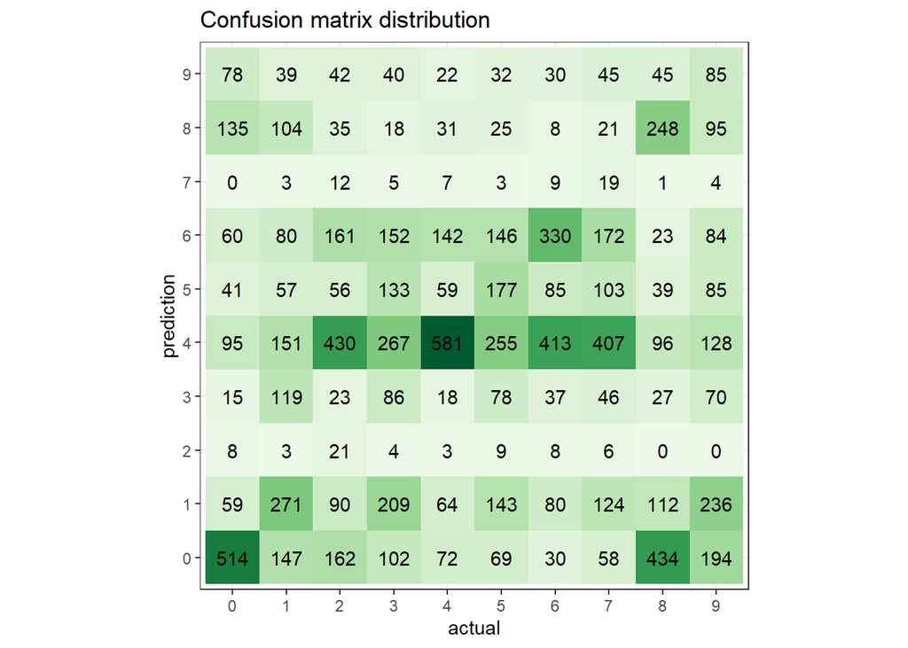

```r
# Plot confusion matrix
cm_baseline = as.data.frame(table(pred, valid)) %>%
  rename(prediction = pred, actual = valid, freq = Freq)

ggplot(cm_baseline, aes(x=actual, y=prediction, fill=freq)) +
  geom_tile() + theme_bw() + coord_equal() +
  scale_fill_distiller(palette="Greens", direction=1) +
  guides(fill=F) + # removing legend for `fill`
  labs(title = "Confusion matrix distribution") + # using a title instead
  geom_text(aes(label=freq), color="black") # printing values
```

## 3.2 Model 1: CNN

Evaluate the CNN model on the validation set, which contains the first 10,000 images with clean labels. The accuracy of the CNN model is 47%, which is much higher than the baseline model’s accuracy.

Based on the line chart below, it is obvious that model 1 showed worse performance on the training dataset compared to the validation dataset. The main reason is because we used noisy labels for training while the valdation was done on the clean labels. In other words, the validation set was much easier (or understandable) for model I. This is a sign that the validation set was sampled from a different distribution as compared to the training dataset, which necessitates the need for a label correction network.

```r
# Predict on first 10,000 images and show results
pred1 = cnn_model1(imgs[1:10000,,,])
class_report(table(pred1, valid))
```

```
## $summary
##    tp   tn  fp  fn precision recall f1_score support
## 0 436 8538 457 569      0.49   0.43     0.46    1005
## 1 655 8337 689 319      0.49   0.67     0.57     974
## 2 303 8577 391 729      0.44   0.29     0.35    1032
## 3 309 8273 711 707      0.30   0.30     0.30    1016
## 4 396 8409 592 603      0.40   0.40     0.40     999
## 5 338 8480 583 599      0.37   0.36     0.36     937
## 6 569 8559 411 461      0.58   0.55     0.57    1030
## 7 499 8538 461 502      0.52   0.50     0.51    1001
## 8 605 8490 485 420      0.56   0.59     0.57    1025
## 9 540 8449 570 441      0.49   0.55     0.52     981
##
## $accuracy
## [1] 0.47
##
## $support
## [1] 10000
```

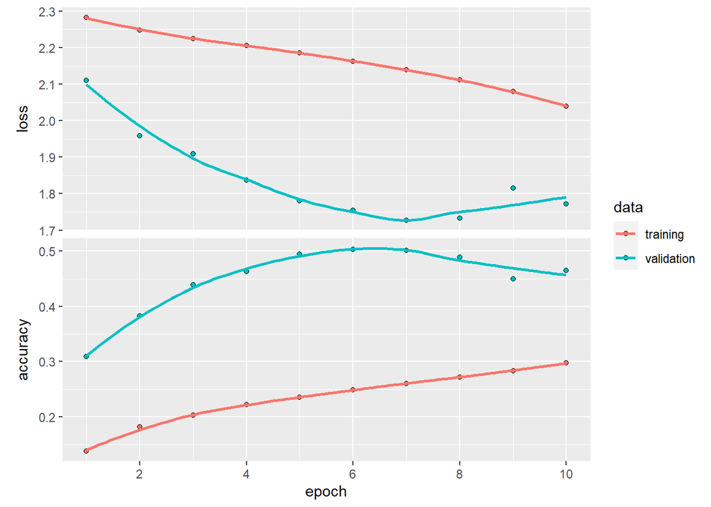

```r
plot(results_train)
```

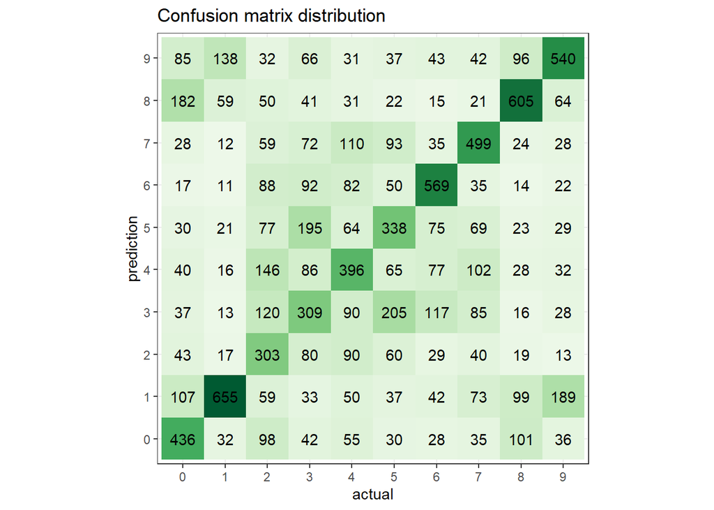

```r
# Plot confusion matrix
cm1 = as.data.frame(table(pred1, valid)) %>%
  rename(prediction = pred1, actual = valid, freq = Freq)

ggplot(cm1, aes(x=actual, y=prediction, fill=freq)) +
  geom_tile() + theme_bw() + coord_equal() +
  scale_fill_distiller(palette="Greens", direction=1) +
  guides(fill=F) + # removing legend for `fill`
  labs(title = "Confusion matrix distribution") + # using a title instead
  geom_text(aes(label=freq), color="black") # printing values
```

## 3.3 Model 2: WSL with CNN

Evaluate the CNN model (WSL) on the validation set, which contains the 3,000 images with clean labels. The accuracy of the CNN model is 56%, which is higher than the accuracy of the baseline model and model 1.

The graph below shows that the validation loss is comparatively higher than the training loss and starts increasing with the training, which is quite counter-intuitive. But this might not be a sign of overfitting. Upon closer inspection, you will realize the accuracy does not drop at the same time. To understand this better, we should take into account that the accuracy is computed comparing the highest output of the softmax with the correct label, and it does not vary depending on the actual value of the softmax output, which is what the validation loss takes into account. And it is also a sign that we should not train this model for too many epochs since it may cause potential overfitting in the future.

```r
# Predict on the 3,000 images and show results
pred2 = cnn_model2(imgs[7001:10000,,,])
class_report(table(pred2, valid[7001:10000]))
```

```
## $summary
##    tp   tn  fp  fn precision recall f1_score support
## 0 171 2582 106 141      0.62   0.55     0.58     312
## 1 219 2571 113  97      0.66   0.69     0.68     316
## 2 110 2597  90 203      0.55   0.35     0.43     313
## 3  68 2584  96 252      0.41   0.21     0.28     320
## 4 166 2505 215 114      0.44   0.59     0.50     280
## 5 153 2502 232 113      0.40   0.58     0.47     266
## 6 188 2586 109 117      0.63   0.62     0.62     305
## 7 171 2622  79 128      0.68   0.57     0.62     299
## 8 230 2552 133  85      0.63   0.73     0.68     315
## 9 192 2567 159  82      0.55   0.70     0.61     274
##
## $accuracy
## [1] 0.56
##
## $support
## [1] 3000
```

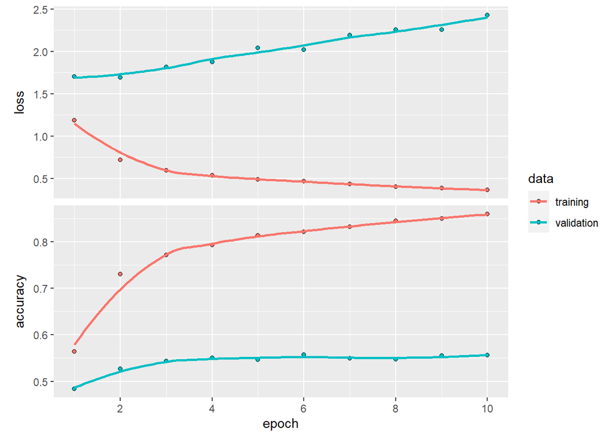

```r
plot(results_train2)
```

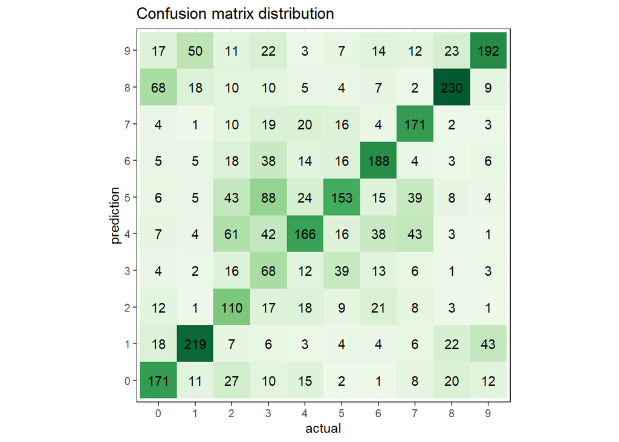

```r
# Plot confusion matrix
cm2 = as.data.frame(table(pred2, valid[7001:10000])) %>%
  rename(prediction = pred2, actual = Var2, freq = Freq)

ggplot(cm2, aes(x=actual, y=prediction, fill=freq)) +
  geom_tile() + theme_bw() + coord_equal() +
  scale_fill_distiller(palette="Greens", direction=1) +
  guides(fill=F) + # removing legend for `fill`
  labs(title = "Confusion matrix distribution") + # using a title instead
  geom_text(aes(label=freq), color="black") # printing values
```

# 4 Predict on hidden test set

Finally, we are given 10,000 images that do not have labels. We will predict the labels and store them as `label_prediction.csv`.

```r
# Load images
n_imgs = 10000
imgs_test = array(NA, c(n_imgs,32,32,3))

for (i in 1:n_imgs) {
  img_fn_test = glue("../data/test_images/test{str_pad(i, 5, pad='0')}.png")
  imgs_test[i,,,] = readPNG(img_fn_test)
  i = i + 1
}

# Predict labels using baseline model
pred_baseline = baseline_model(imgs_test)

# Predict labels using model 1
pred_mod1 = cnn_model1(imgs_test)

# Predict labels using model 2
pred_mod2 = cnn_model2(imgs_test)

# Output to csv file
pred_results = data.frame("Index" = glue("test{str_pad(1:n_imgs, 5, pad='0')}"),
                          "Baseline" = pred_baseline,
                          "Model I" = pred_mod1,
                          "Model II" = pred_mod2,
                          check.names = FALSE)
write.csv(pred_results, "../output/label_prediction.csv", row.names = FALSE)
```